# Student Habits vs Academic Performance

Data Programming 2025 - Project

Author

Affiliation

Zhivko Stoimchev

FAMNIT, University of Primorska

Published

June 7, 2025

# Introduction

Students develop all kinds of habits during their school years. Some pull all-nighters before exams, while others stick to regular study schedules. Some prioritize eight hours of sleep, and others survive on much less. Screen time varies too - from minimal use to constant scrolling. These daily choices likely impact academic performance, but which ones matter most?

## The problem

While we often hear advice about good study habits, there’s surprisingly little clear evidence about which routines actually lead to better grades. Professors recommend certain approaches, students develop their own methods, and parents suggest what worked in their day. But with so many factors involved - study time, sleep, technology use, and more - it’s hard to know what really makes a difference in academic success.

## Objectives

This project aims to:

- Examine how different study approaches affect grades
- Measure the relationship between sleep patterns and academic performance
- Analyze whether screen time helps or hurts school results
- Provide visual evidence of what habits correlate with success

# Libraries

```r
library(tidyverse)
library(skimr)
library(knitr)
library(psych)
library(janitor)
library(ggplot2)
```

# Data presentation

The analysis uses data from 1,000 students to identify which daily routines tend to accompany better grades. This dataset was obtained from Kaggle(Nath (n.d.)). It does not include any missing values, and all columns are complete. The dataset contains information about students’ study habits, social media usage, sleep patterns, and academic performance.

## Data columns

The dataset consists of 1,000 rows and 16 columns. Each row represents a student, and the columns contain information about their study habits and academic performance. The columns are as follows:

| Name | Description | Type |
| --- | --- | --- |
| student_id | Unique identifier for each student | Character |
| age | Student’s age in years | Numeric |
| gender | Student’s gender (Male/Female/Other) | Factor |
| study_hours_per_day | Daily hours spent studying | Numeric |
| social_media_hours | Daily hours spent on social media | Numeric |
| netflix_hours | Daily hours spent watching Netflix | Numeric |
| part_time_job | Whether student has a job (Yes/No) | Logical |
| attendance_percentage | Class attendance rate (0-100%) | Numeric |
| sleep_hours | Average nightly sleep duration | Numeric |
| diet_quality | Self-reported diet quality (Poor/Fair/Good) | Factor |
| exercise_frequency | Weekly exercise sessions | Numeric |
| parental_education_level | Highest parental education | Factor |
| internet_quality | Quality of internet access | Factor |
| mental_health_rating | Self-rated mental health (1-10 scale) | Numeric |
| extracurricular_participation | Whether student does extracurriculars | Logical |
| exam_score | Final exam score (0-100 scale) | Numeric |

## Presentation of the Data

```r
data <- read_csv("student_habits_performance.csv")
head(data, 5) %>% kable()
```

| student_id | age | gender | study_hours_per_day | social_media_hours | netflix_hours | part_time_job | attendance_percentage | sleep_hours | diet_quality | exercise_frequency | parental_education_level | internet_quality | mental_health_rating | extracurricular_participation | exam_score |
| --- | --- | --- | --- | --- | --- | --- | --- | --- | --- | --- | --- | --- | --- | --- | --- |
| S1000 | 23 | Female | 0.0 | 1.2 | 1.1 | No | 85.0 | 8.0 | Fair | 6 | Master | Average | 8 | Yes | 56.2 |
| S1001 | 20 | Female | 6.9 | 2.8 | 2.3 | No | 97.3 | 4.6 | Good | 6 | High School | Average | 8 | No | 100.0 |
| S1002 | 21 | Male | 1.4 | 3.1 | 1.3 | No | 94.8 | 8.0 | Poor | 1 | High School | Poor | 1 | No | 34.3 |
| S1003 | 23 | Female | 1.0 | 3.9 | 1.0 | No | 71.0 | 9.2 | Poor | 4 | Master | Good | 1 | Yes | 26.8 |
| S1004 | 19 | Female | 5.0 | 4.4 | 0.5 | No | 90.9 | 4.9 | Fair | 3 | Master | Good | 1 | No | 66.4 |

```r
skim(data)
```

Data summary

| Name | data |
| --- | --- |
| Number of rows | 1000 |
| Number of columns | 16 |
| _______________________ |  |
| Column type frequency: |  |
| character | 7 |
| numeric | 9 |
| ________________________ |  |
| Group variables | None |

**Variable type: character**

| skim_variable | n_missing | complete_rate | min | max | empty | n_unique | whitespace |
| --- | --- | --- | --- | --- | --- | --- | --- |
| student_id | 0 | 1 | 5 | 5 | 0 | 1000 | 0 |
| gender | 0 | 1 | 4 | 6 | 0 | 3 | 0 |
| part_time_job | 0 | 1 | 2 | 3 | 0 | 2 | 0 |
| diet_quality | 0 | 1 | 4 | 4 | 0 | 3 | 0 |
| parental_education_level | 0 | 1 | 4 | 11 | 0 | 4 | 0 |
| internet_quality | 0 | 1 | 4 | 7 | 0 | 3 | 0 |
| extracurricular_participation | 0 | 1 | 2 | 3 | 0 | 2 | 0 |

**Variable type: numeric**

| skim_variable | n_missing | complete_rate | mean | sd | p0 | p25 | p50 | p75 | p100 | hist |
| --- | --- | --- | --- | --- | --- | --- | --- | --- | --- | --- |
| age | 0 | 1 | 20.50 | 2.31 | 17.0 | 18.75 | 20.0 | 23.00 | 24.0 | ▇▃▇▃▇ |
| study_hours_per_day | 0 | 1 | 3.55 | 1.47 | 0.0 | 2.60 | 3.5 | 4.50 | 8.3 | ▂▇▇▃▁ |
| social_media_hours | 0 | 1 | 2.51 | 1.17 | 0.0 | 1.70 | 2.5 | 3.30 | 7.2 | ▃▇▆▁▁ |
| netflix_hours | 0 | 1 | 1.82 | 1.08 | 0.0 | 1.00 | 1.8 | 2.52 | 5.4 | ▆▇▆▂▁ |
| attendance_percentage | 0 | 1 | 84.13 | 9.40 | 56.0 | 78.00 | 84.4 | 91.03 | 100.0 | ▁▂▆▇▆ |
| sleep_hours | 0 | 1 | 6.47 | 1.23 | 3.2 | 5.60 | 6.5 | 7.30 | 10.0 | ▁▆▇▅▁ |
| exercise_frequency | 0 | 1 | 3.04 | 2.03 | 0.0 | 1.00 | 3.0 | 5.00 | 6.0 | ▇▃▅▃▇ |
| mental_health_rating | 0 | 1 | 5.44 | 2.85 | 1.0 | 3.00 | 5.0 | 8.00 | 10.0 | ▇▇▇▇▇ |
| exam_score | 0 | 1 | 69.60 | 16.89 | 18.4 | 58.48 | 70.5 | 81.32 | 100.0 | ▁▃▆▇▅ |

```r
data %>%
  clean_names() %>%
  describe() %>%
  kable()
```

|  | vars | n | mean | sd | median | trimmed | mad | min | max | range | skew | kurtosis | se |
| --- | --- | --- | --- | --- | --- | --- | --- | --- | --- | --- | --- | --- | --- |
| student_id* | 1 | 1000 | 500.5000 | 288.8194361 | 500.5 | 500.500000 | 370.65000 | 1.0 | 1000.0 | 999.0 | 0.0000000 | -1.2036006 | 9.1332725 |
| age | 2 | 1000 | 20.4980 | 2.3080995 | 20.0 | 20.497500 | 2.96520 | 17.0 | 24.0 | 7.0 | 0.0084118 | -1.2224618 | 0.0729885 |
| gender* | 3 | 1000 | 1.5610 | 0.5749866 | 2.0 | 1.523750 | 1.48260 | 1.0 | 3.0 | 2.0 | 0.4239012 | -0.7543984 | 0.0181827 |
| study_hours_per_day | 4 | 1000 | 3.5501 | 1.4688899 | 3.5 | 3.547000 | 1.48260 | 0.0 | 8.3 | 8.3 | 0.0540905 | -0.0672423 | 0.0464504 |
| social_media_hours | 5 | 1000 | 2.5055 | 1.1724224 | 2.5 | 2.496875 | 1.18608 | 0.0 | 7.2 | 7.2 | 0.1194460 | -0.1054042 | 0.0370753 |
| netflix_hours | 6 | 1000 | 1.8197 | 1.0751176 | 1.8 | 1.793625 | 1.18608 | 0.0 | 5.4 | 5.4 | 0.2364434 | -0.4418153 | 0.0339982 |
| part_time_job* | 7 | 1000 | 1.2150 | 0.4110279 | 1.0 | 1.143750 | 0.00000 | 1.0 | 2.0 | 1.0 | 1.3853804 | -0.0807990 | 0.0129978 |
| attendance_percentage | 8 | 1000 | 84.1317 | 9.3992463 | 84.4 | 84.374500 | 9.63690 | 56.0 | 100.0 | 44.0 | -0.2370975 | -0.3999624 | 0.2972303 |
| sleep_hours | 9 | 1000 | 6.4701 | 1.2263768 | 6.5 | 6.457625 | 1.33434 | 3.2 | 10.0 | 6.8 | 0.0912097 | -0.2247917 | 0.0387814 |
| diet_quality* | 10 | 1000 | 1.7480 | 0.7476998 | 2.0 | 1.685000 | 1.48260 | 1.0 | 3.0 | 2.0 | 0.4455110 | -1.1030338 | 0.0236443 |
| exercise_frequency | 11 | 1000 | 3.0420 | 2.0254230 | 3.0 | 3.052500 | 2.96520 | 0.0 | 6.0 | 6.0 | -0.0318273 | -1.2795924 | 0.0640495 |
| parental_education_level* | 12 | 1000 | 1.9990 | 0.9390851 | 2.0 | 1.885000 | 1.48260 | 1.0 | 4.0 | 3.0 | 0.6612758 | -0.4602674 | 0.0296965 |
| internet_quality* | 13 | 1000 | 1.7710 | 0.7078560 | 2.0 | 1.713750 | 1.48260 | 1.0 | 3.0 | 2.0 | 0.3577693 | -0.9726652 | 0.0223844 |
| mental_health_rating | 14 | 1000 | 5.4380 | 2.8475014 | 5.0 | 5.423750 | 2.96520 | 1.0 | 10.0 | 9.0 | 0.0376973 | -1.1922821 | 0.0900459 |
| extracurricular_participation* | 15 | 1000 | 1.3180 | 0.4659325 | 1.0 | 1.272500 | 0.00000 | 1.0 | 2.0 | 1.0 | 0.7804478 | -1.3922905 | 0.0147341 |
| exam_score | 16 | 1000 | 69.6015 | 16.8885639 | 70.5 | 69.812375 | 17.19816 | 18.4 | 100.0 | 81.6 | -0.1558819 | -0.4289548 | 0.5340633 |

# Transformation of data

Through grouping and normalization, student patterns will be uncovered, revealing how study habits, sleep, and screen time relate to academic performance.

## Categorizing students based on study intensity

```r
data_with_study_levels <- data %>%
  mutate(study_intensity = case_when(
    study_hours_per_day < 2 ~ "Light",
    study_hours_per_day >= 2 & study_hours_per_day < 4 ~ "Moderate",
    study_hours_per_day >= 4 ~ "Intense"
  ))

data_with_study_levels %>%
  group_by(study_intensity) %>%
  slice_sample(n = 2) %>%
  select(student_id, study_hours_per_day, study_intensity, exam_score) %>%
  arrange(study_intensity, study_hours_per_day) %>%
  kable(caption = "Representative Students from Each Study Intensity Level")
```

Representative Students from Each Study Intensity Level

| student_id | study_hours_per_day | study_intensity | exam_score |
| --- | --- | --- | --- |
| S1802 | 4.3 | Intense | 82.9 |
| S1638 | 5.1 | Intense | 99.4 |
| S1790 | 0.8 | Light | 31.5 |
| S1692 | 1.7 | Light | 37.4 |
| S1344 | 3.2 | Moderate | 81.7 |
| S1860 | 3.6 | Moderate | 65.6 |

This categorizes students into three study intensity levels based on their daily study hours:

- **Light**: < 2 hours
- **Moderate**: 2 to 4 hours
- **Intense**: 4 or more hours

We can see that students with more intense study habits tend to perform better academically.

## Screen time categorization

```r
categorize_screen_time <- function(social_media, netflix) {
  case_when(
    (social_media + netflix) > 6 ~ "Very High",
    (social_media + netflix) > 4 ~ "High",
    (social_media + netflix) > 2 ~ "Moderate",
    TRUE ~ "Low"
  )
}

screen_time_data <- data %>%
  mutate(screen_time_level = categorize_screen_time(social_media_hours, netflix_hours))

screen_time_data %>%
  count(screen_time_level) %>%
  arrange(desc(n)) %>%
  kable(caption = "Number of students by Screen Time Level")
```

Number of students by Screen Time Level

| screen_time_level | n |
| --- | --- |
| High | 429 |
| Moderate | 346 |
| Very High | 135 |
| Low | 90 |

In this transformation, students are categorized based on their combined social media and Netflix usage into four levels, namely:

- **Low**: 2 hours or less
- **Moderate**: 2 to 4 hours
- **High**: 4 to 6 hours
- **Very High**: More than 6 hours

We can see that most of the students fall into the “High” screen time category, with a significant number also in the “Moderate” category. This suggests that many students balance their screen time with other activities.

## Gender Based Comparison

```r
data %>%
  group_by(gender) %>%
  summarize(avg_exam_score = mean(exam_score, na.rm = TRUE),
            avg_study_hours = mean(study_hours_per_day, na.rm = TRUE),
            avg_sleep_hours = mean(sleep_hours, na.rm = TRUE)) %>%
  kable(caption = "Correlation between genders and exam scores")
```

Correlation between genders and exam scores

| gender | avg_exam_score | avg_study_hours | avg_sleep_hours |
| --- | --- | --- | --- |
| Female | 69.74137 | 3.583784 | 6.471726 |
| Male | 69.36834 | 3.510692 | 6.438994 |
| Other | 70.64762 | 3.611905 | 6.804762 |

From the results above, we can see that students who identify as “Other” have the highest average exam score (70.65) and the most sleep (6.80 hours), while females study slightly more (3.58 hours) and score higher than males, whose averages are marginally lower in all categories.

## Average Performance per Performance Level

```r
data %>%
  mutate(performance_group = case_when(
    exam_score < 50 ~ "Fail",
    exam_score >= 50 & exam_score < 60 ~ "Sufficient",
    exam_score >= 60 & exam_score < 70 ~ "Satisfactory",
    exam_score >= 70 & exam_score < 80 ~ "Good",
    exam_score >= 80 & exam_score < 90 ~ "Very Good",
    exam_score >= 90 & exam_score < 100 ~ "Excellent",
    exam_score == 100 ~ "Outstanding"
  )) -> data
```

Added `performance_group` column to categorize students based on their exam scores. The categories are defined as follows:

- **Fail**: exam score < 50
- **Sufficient**: 50 <= exam score < 60
- **Satisfactory**: 60 <= exam score < 70
- **Good**: 70 <= exam score < 80
- **Very Good**: 80 <= exam score < 90
- **Excellent**: 90 <= exam score < 100
- **Outstanding**: exam score = 100

### Performance Groups Summary

```r
data %>%
  group_by(performance_group) %>%
  summarize(n_students = n(),
            avg_exam_score = mean(exam_score, na.rm = TRUE),
            avg_study_hours = mean(study_hours_per_day, na.rm = TRUE),
            avg_attendance_hours = mean(attendance_percentage, na.rm = TRUE),
            avg_sleep_hours = mean(sleep_hours, na.rm = TRUE),
            avg_social_media_hours = mean(social_media_hours, na.rm = TRUE),
            avg_netflix_hours = mean(netflix_hours, na.rm = TRUE)) %>%
  arrange(desc(avg_exam_score)) -> data_stats

data_stats %>%
    kable()
```

| performance_group | n_students | avg_exam_score | avg_study_hours | avg_attendance_hours | avg_sleep_hours | avg_social_media_hours | avg_netflix_hours |
| --- | --- | --- | --- | --- | --- | --- | --- |
| Outstanding | 48 | 100.00000 | 6.235417 | 86.75833 | 6.850000 | 2.254167 | 1.431250 |
| Excellent | 78 | 94.93462 | 5.271795 | 86.82949 | 6.637180 | 2.291026 | 1.644872 |
| Very Good | 151 | 84.47219 | 4.525166 | 84.42119 | 6.650331 | 2.143709 | 1.653642 |
| Good | 234 | 74.39017 | 3.801709 | 84.34359 | 6.525641 | 2.503846 | 1.708120 |
| Satisfactory | 209 | 65.00383 | 3.312440 | 83.10957 | 6.377512 | 2.586603 | 1.914354 |
| Sufficient | 149 | 55.12886 | 2.427517 | 83.41544 | 6.226846 | 2.630201 | 1.961745 |
| Fail | 131 | 41.48092 | 1.623664 | 83.29618 | 6.348855 | 2.874046 | 2.144275 |

This transformation categorizes students by exam performance and calculates average metrics for each group. The results reveal clear patterns: *higher-performing students study more and use less screen time*, while sleep and attendance show minimal variation across groups.

### The most dominant group

```r
data_stats %>%
  mutate(n_percentage = n_students / sum(n_students) * 100) %>%
  select(performance_group, avg_exam_score, avg_study_hours, n_students, n_percentage) %>%
  arrange(desc(n_students)) %>%
  kable(caption = "Performance Groups Overview")
```

Performance Groups Overview

| performance_group | avg_exam_score | avg_study_hours | n_students | n_percentage |
| --- | --- | --- | --- | --- |
| Good | 74.39017 | 3.801709 | 234 | 23.4 |
| Satisfactory | 65.00383 | 3.312440 | 209 | 20.9 |
| Very Good | 84.47219 | 4.525166 | 151 | 15.1 |
| Sufficient | 55.12886 | 2.427517 | 149 | 14.9 |
| Fail | 41.48092 | 1.623664 | 131 | 13.1 |
| Excellent | 94.93462 | 5.271795 | 78 | 7.8 |
| Outstanding | 100.00000 | 6.235417 | 48 | 4.8 |

The most common performance group is “Good” with 234 students, balancing study hours (3.80) and maintaining solid exam scores (74.40).

### Study hours, attendance rate and exam scores

```r
data_stats %>%
  mutate(
    norm_study_hours = scale(avg_study_hours),
    norm_attendance = scale(avg_attendance_hours),
    importance = ifelse(norm_study_hours > norm_attendance, "Study Matters", "Attendance Matters")
  ) %>%
  select(performance_group, avg_exam_score, norm_study_hours, norm_attendance, importance) %>%
  arrange(desc(avg_exam_score)) %>%
  kable(caption = "Correlation between Study Hours, Attendance and Exam Scores")
```

Correlation between Study Hours, Attendance and Exam Scores

| performance_group | avg_exam_score | norm_study_hours | norm_attendance | importance |
| --- | --- | --- | --- | --- |
| Outstanding | 100.00000 | 1.46542714 | 1.3650924 | Study Matters |
| Excellent | 94.93462 | 0.86453370 | 1.4100175 | Attendance Matters |
| Very Good | 84.47219 | 0.39895202 | -0.1105318 | Study Matters |
| Good | 74.39017 | -0.05217939 | -0.1595283 | Study Matters |
| Satisfactory | 65.00383 | -0.35727695 | -0.9386641 | Study Matters |
| Sufficient | 55.12886 | -0.90909581 | -0.7455459 | Attendance Matters |
| Fail | 41.48092 | -1.41036072 | -0.8208398 | Attendance Matters |

Students who study more tend to perform better. The “Outstanding” group has the highest average study hours (normalized) and the best exam scores, while the “Fail” group has the lowest study hours (normalized) and exam scores. Attendance percentages remain stable across all performance groups, indicating that while attendance is important, it does not directly correlate with higher exam scores **(study time matters more).**

### Sleep hours among all the groups

```r
data_stats %>%
  select(performance_group, avg_sleep_hours) %>%
  arrange(desc(avg_sleep_hours)) %>%
  kable(caption = "Correlation between Sleep Hours and Performance Groups")
```

Correlation between Sleep Hours and Performance Groups

| performance_group | avg_sleep_hours |
| --- | --- |
| Outstanding | 6.850000 |
| Very Good | 6.650331 |
| Excellent | 6.637180 |
| Good | 6.525641 |
| Satisfactory | 6.377512 |
| Fail | 6.348855 |
| Sufficient | 6.226846 |

Across all performance groups, sleep hours remain consistent (around 6-6.8 hours), suggesting that sleep does not directly determine academic success.

## Identifying High Screen-Time Students

```r
data %>%
  summarize(
    overall_avg_exam_score = mean(exam_score, na.rm = TRUE),
    high_screen_time_avg_exam_score = mean(exam_score[social_media_hours > 5 | netflix_hours > 5], na.rm = TRUE)
  ) %>%
  kable()
```

| overall_avg_exam_score | high_screen_time_avg_exam_score |
| --- | --- |
| 69.6015 | 65.85833 |

People who spend more than 5 hours on social media or Netflix have an average exam score of 65.86, which is below the overall average of 69.60. This suggests that high screen time may negatively impact academic performance.

# Exploratory data analysis

## Distribution of Students by Performance Group (Bar Plot)

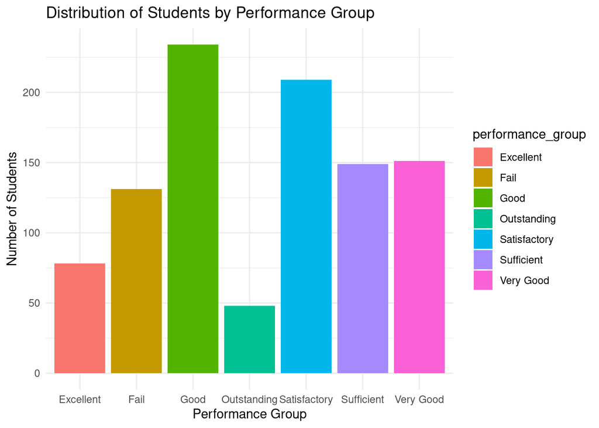

```r
data %>%
  count(performance_group) %>%
  ggplot(aes(x = performance_group, y = n, fill = performance_group)) +
  geom_bar(stat = "identity") +
  theme_minimal() +
  labs(title = "Distribution of Students by Performance Group", x = "Performance Group", y = "Number of Students")
```

The bar chart displays distribution of students across different performance categories. The highest number of students fall in the group “Good”, followed by “Satisfactory”. The lowest number appears in the “Outstanding” and “Excellent” groups, indicating a lot of people struggle to achieve top scores. Overall, the trend is that an average student has average to above-average results.

## Study Hours vs Exam Score (Scatter Plot)

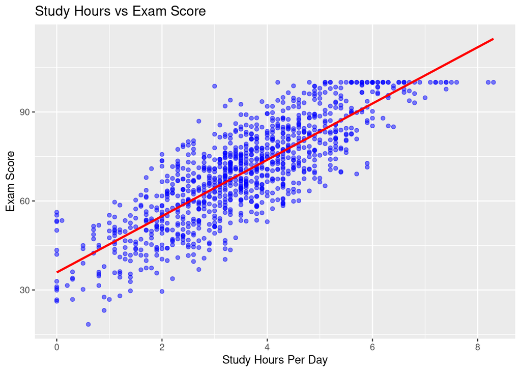

```r
ggplot(data, aes(x = study_hours_per_day, y = exam_score)) +
  geom_point(alpha = 0.5, color = "blue") +
  geom_smooth(method = "lm", col = "red", se = FALSE) +
  labs(title = "Study Hours vs Exam Score", x = "Study Hours Per Day", y = "Exam Score")
```

## Sleep Hours by Performance Group (Box Plot)

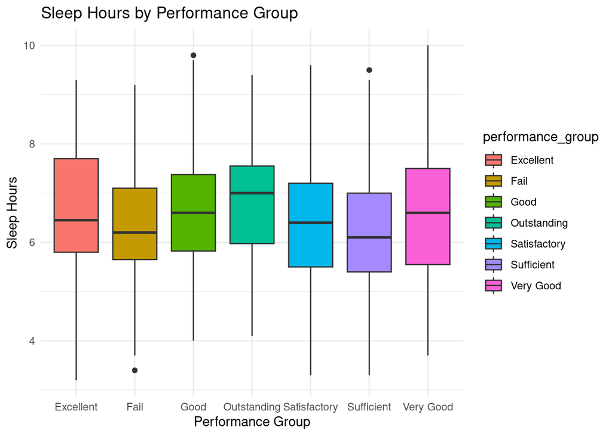

```r
ggplot(data, aes(x = performance_group, y = sleep_hours, fill = performance_group)) +
  geom_boxplot() +
  theme_minimal() +
  labs(title = "Sleep Hours by Performance Group", x = "Performance Group", y = "Sleep Hours")
```

## Exam Score Distribution by Study Intensity (density plot)

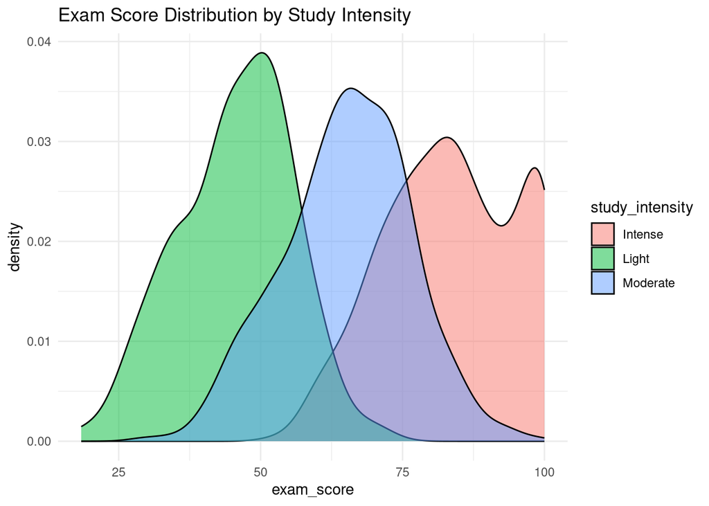

```r
ggplot(data_with_study_levels, aes(x = exam_score, fill = study_intensity)) +
  geom_density(alpha = 0.5) +
  theme_minimal() +
  labs(title = "Exam Score Distribution by Study Intensity")
```

This density plot compares exam score distributions across study intensity levels. The horizontal axis represents exam scores, while the vertical axis shows the density of students achieving those scores.

# Conclusion

Up until now, the analysis reveals three key insights about student performance, namely:

1. **Study time matters most**: Students scoring higher results tend to study more, although attendance rates remain consistent across performance groups.
2. **Screen time hurts**: Students with high social media or Netflix usage (over 5 hours daily) score lower on exams, meaning entertainment distractions have negative impact on performance.
3. **Sleep is consistent**: All groups average 6-7 hours, suggesting it’s a baseline requirement.

## Visualizing distributions

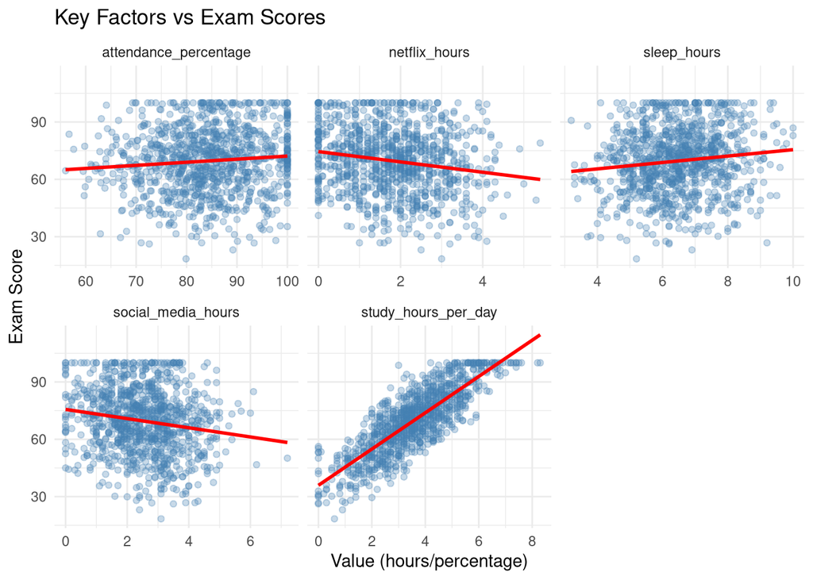

```r
data %>%
  select(exam_score, study_hours_per_day, social_media_hours,
         netflix_hours, sleep_hours, attendance_percentage) %>%
  pivot_longer(-exam_score, names_to = "metric", values_to = "value") %>%
  ggplot(aes(x = value, y = exam_score)) +
  geom_point(alpha = 0.3, color = "steelblue") +
  geom_smooth(method = "lm", color = "red", se = FALSE) +
  facet_wrap(~metric, scales = "free_x", ncol = 3) +
  labs(title = "Key Factors vs Exam Scores",
       x = "Value (hours/percentage)",
       y = "Exam Score") +
  theme_minimal()
```

In summary, the analysis highlights the importance of study habits and their impact on academic performance. Students who dedicate more time to studying tend to achieve better exam scores, while excessive screen time can hinder their success. Sleep duration remains relatively stable across performance groups, suggesting it is a necessary foundation for academic achievement.

## References

Nath, Jayanta. n.d. “Student Habits Vs Academic Performance.” https://www.kaggle.com/datasets/jayaantanaath/student-habits-vs-academic-performance.